# Bayesian Statistics

Introduction

Fall 2020

# Examples from Bayesian Stats Course (Columbia, Fall 2020)

## Example 1a: Bayes Rule

You go to the doctor for a COVID-19 rapid test. Let `theta` represent your true state: `theta` = 1 if you are infected with the virus, and `theta` = 0 if you are not. Let `y` denote the result of the test: `y` = 1 if the test comes back positive and `y` = 0 if the test is negative. The probability of a correct result for an infected subject is called the sensitivity of the test (`Pr(y=1|theta=1)`), we will denote it `p` here. The probability of correct result for one not infected with the virus is called the specificity (`Pr(Y=0|theta=0)`), denoted as `q.`

Do you have the virus? Of course you don’t know. In Bayesian statistics we describe our uncertainty about the world by assigning probabilities to various states. Suppose your prior probability of being infected is `pi`. That is, the marginal probability `Pr(theta = 1) = pi` .

With this information we can define the following:

- `pi` as the prior prob of infection (“prevalence”): `pi = Pr(theta=1)`
- `q0` is the false positive probability: `q0 = Pr(Y=1|theta=0)`
- `q1` is the true positive probability: `q1 = Pr(Y=1|theta=1)`. This is also called the sensitivity of the test; `1-q0` is the specificity of the test.

We set the following values in R:

```r
pi <- .04   # 20% of population is infected
q1 <- .90  # test has sensitivity of .90
q0 <- .08  # test has specificity of .92
```

With this we can compute the posterior probabilities, given test result.

The probability of infection, before the test result is available is `pi`:

```r
pi  # Prob of infection, before test result is available
```

```
## [1] 0.04
```

The probability of infection given a positive test is:
$$Pr(\theta|y_1 =1) = \frac{Pr(\theta = 1, y_1 = 1)}{Pr(y_1=1)} = \frac{Pr(\theta=1)Pr(y_1=1|\theta=1)}{Pr(y_1=1)} = \frac{\pi p }{\pi p + (1-\pi)q}$$

```r
pi * q1 / (pi*q1 + (1-pi)*q0)  # Prob of infection given positive test result
```

```
## [1] 0.3191489
```

The probability of infection given a negative test is:
$$Pr(\theta|y_1 =0) = \frac{Pr(\theta = 1, y_1 = 1)}{Pr(y_1=0)} = \frac{Pr(\theta=1)Pr(y_1=0|\theta=1)}{Pr(y_1=0)} = \frac{\pi (1-p) }{\pi (1-p) + (1-\pi)(1-q)}$$

```r
pi*(1-q1) / (pi*(1-q1) + (1-pi)*(1-q0))  # Prob of infection if test negative
```

```
## [1] 0.004508566
```

Plot posterior probability versus prior probability:

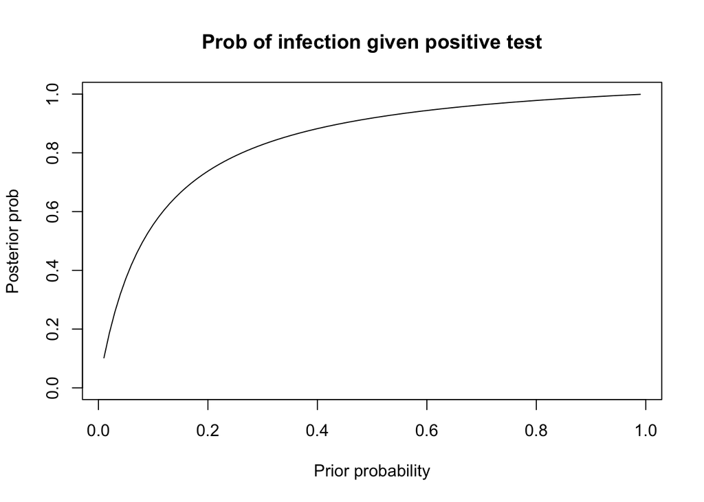

```r
post.prob <- function(pi, q0, q1)
{
  pi * q1 / (pi*q1 + (1-pi)*q0)
}

grid <- seq(.01, .99, .01)

plot(grid, post.prob(pi=grid, q0=q0, q1=q1), type="l",
     xlab="Prior probability", ylab="Posterior prob",
     main="Prob of infection given positive test", ylim=c(0,1))
```

That’s how the posterior prob varies with prior prob

What about the sensitivity and specificity of the test?

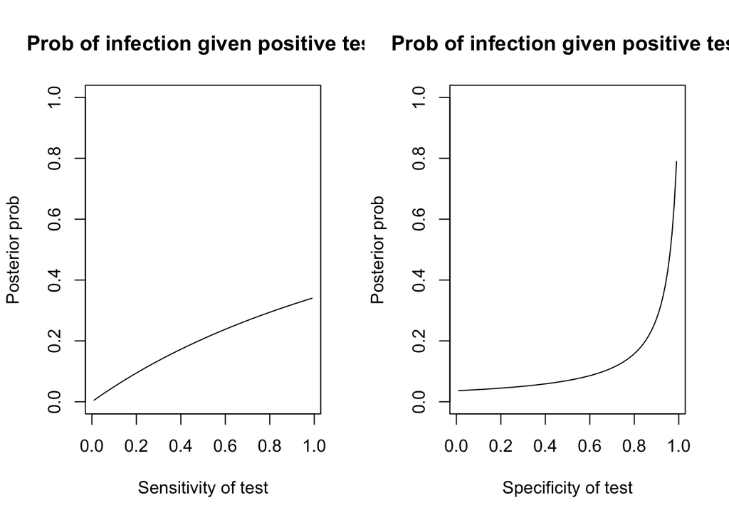

```r
op <- par(mfrow=c(1,2))

plot(grid, post.prob(pi=pi, q1=grid, q0=q0), type="l",
     xlab="Sensitivity of test", ylab="Posterior prob",
     main="Prob of infection given positive test", ylim=c(0,1))

plot(grid, post.prob(pi=pi, q1=q1, q0=1-grid), type="l",
     xlab="Specificity of test", ylab="Posterior prob",
     main="Prob of infection given positive test", ylim=c(0,1))
```

```r
par(op)
```

### Monte Carlo approximation

Simulate the joint distribution of theta and Y:

```r
S <- 1000;  theta <- NULL;  y <- NULL;

for(s in 1:S)
{
  theta[s] <- rbinom(1, 1, pi)
  prob <- ifelse(theta[s]==1, q1, q0)
  y[s] <- rbinom(1, 1, prob)
}

table(theta, y) / S  # approximate joint distribution
```

```
##      y
## theta     0     1
##     0 0.881 0.084
##     1 0.001 0.034
```

```r
mean(theta[y==1])  #  Monte Carlo approx to posterior prob
```

```
## [1] 0.2881356
```

Of course there’s no real need for Monte Carlo, when the exact joint distribution is available by straightforward calculation:

```r
joint <- matrix(c((1-pi)*(1-q0), pi*(1-q1), (1-pi)*q0, pi*q1), 2,2)

rownames(joint) <- c("theta=0", "theta=1")

colnames(joint) <- c("y=0", "y=1")

joint
```

```
##            y=0    y=1
## theta=0 0.8832 0.0768
## theta=1 0.0040 0.0360
```

```r
joint[2,2] / sum(joint[,2])
```

```
## [1] 0.3191489
```

## Example 1b: Beta-Binomial Model

Create data:

```r
rm(list=ls())

n <- 100;  y <- 60;

theta <- seq(0,1,.01)
```

Hyperparameters:

```r
a          <- c(1,.5,2,20)
b          <- c(1,.5,2, 1)
```

Calculations:

```r
post_mean  <- (y+a)/(n+a+b)
post_var   <- (y+a)*(n-y+b)/((n+a+b)^2 * (n+a+b+1))
post_sd    <- sqrt(post_var)
post_PG5   <- 1-pbeta(0.5,a+y,b+n-y)
pri_mean   <- (a)/(a+b)
pri_var    <- (a)*(b)/((a+b)*(a+b)*(a+b+1))
pri_sd     <- sqrt(pri_var)
pri_PG5    <- 1-pbeta(0.5,a,b)
```

Summary plot of prior and posterior on same axes

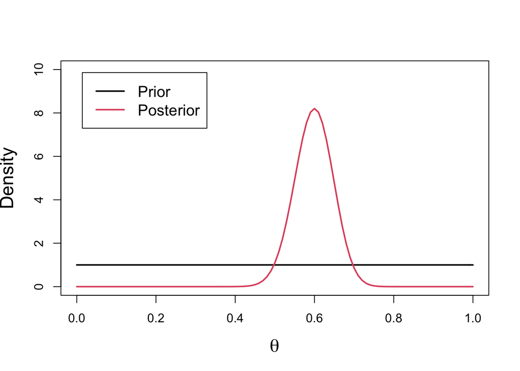

```r
plot(theta,dbeta(theta,1,1),lwd=2,type="l",
     xlab=expression(theta), ylab="Density",
     ylim=c(0,10), cex.lab=1.5)

legend("topleft", c("Prior","Posterior"), col=1:2,
       lwd=2, inset=0.05, cex=1.25)

lines(theta, dbeta(theta,y+1,n-y+1), col=2, lwd=2)
```

Consider four different priors:

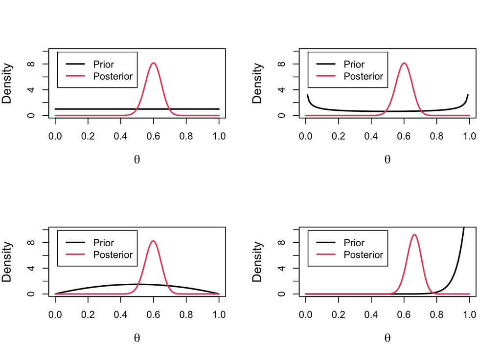

```r
op <- par(mfrow=c(2,2))

for(j in 1:4)
{
  plot(theta,dbeta(theta,a[j],b[j]), lwd=2, type="l", ylim=c(0,10),
       xlab=expression(theta), ylab="Density",cex.lab=1.25)
  legend("topleft",c("Prior","Posterior"),col=1:2,lwd=2,inset=0.05)
  lines(theta,dbeta(theta,y+a[j],n-y+b[j]),col=2,lwd=2)
}
```

```r
par(op)
```

Compare the four priors to each other (ignoring data)

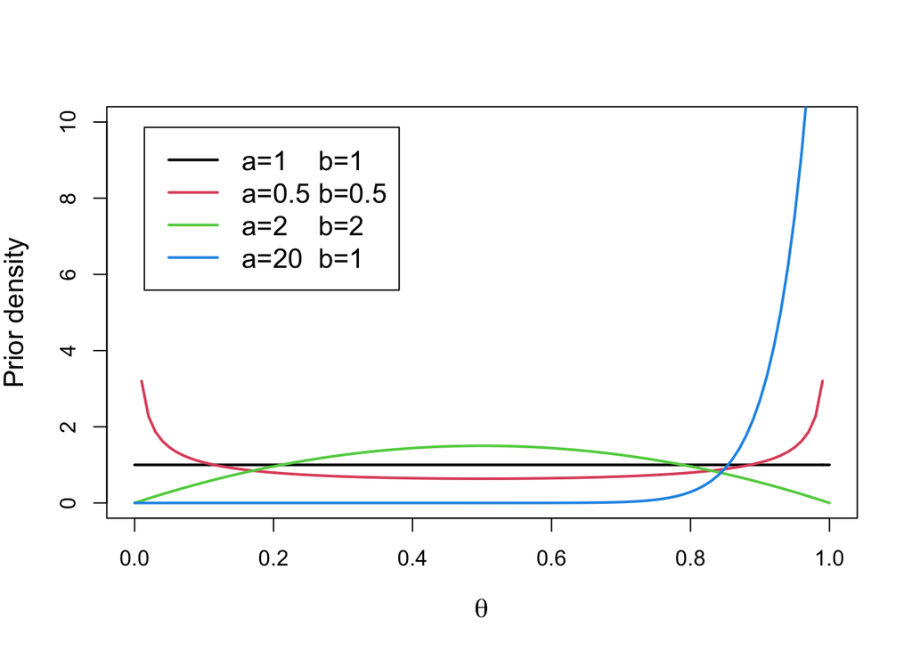

```r
plot(NA, xlim=0:1, xlab=expression(theta), ylab="Prior density",
     ylim=c(0,10), cex.lab=1.25)

for(j in 1:4)
{
  lines(theta, dbeta(theta, a[j], b[j]), col=j, lwd=2)
}

legend("topleft",
       c("a=1    b=1","a=0.5 b=0.5", "a=2    b=2","a=20  b=1"),
       col=1:4, lwd=2, inset=0.05, cex=1.25)
```

Compare the four posteriors (single set of axes)

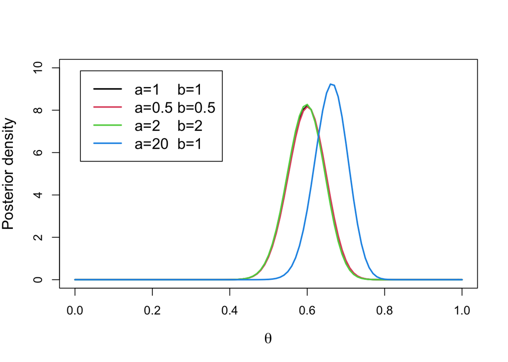

```r
plot(NA, xlim=0:1, xlab=expression(theta), ylab="Posterior density",
     ylim=c(0,10), cex.lab=1.25)

for(j in 1:4)
{
  lines(theta, dbeta(theta, y+a[j], n-y+b[j]), col=j, lwd=2)
}

legend("topleft",
       c("a=1    b=1","a=0.5 b=0.5", "a=2    b=2","a=20  b=1"),
       col=1:4, lwd=2, inset=0.05, cex=1.25)
```

Numerical summaries

```r
round(cbind(a, b, pri_mean, pri_sd, pri_PG5,
            post_mean, post_sd, post_PG5), 2)
```

```
##         a   b pri_mean pri_sd pri_PG5 post_mean post_sd post_PG5
## [1,]  1.0 1.0     0.50   0.29     0.5      0.60    0.05     0.98
## [2,]  0.5 0.5     0.50   0.35     0.5      0.60    0.05     0.98
## [3,]  2.0 2.0     0.50   0.22     0.5      0.60    0.05     0.98
## [4,] 20.0 1.0     0.95   0.05     1.0      0.66    0.04     1.00
```

## Example 1c: Summarizing a Posterior

```r
rm(list=ls()); set.seed(20200909);
```

Data

```r
y <- 8; n <- 10
```

The posterior is theta|y~Beta(A,B)

```r
A <- y+1; B <- n-y+1
```

Posterior mean

```r
A/(A+B)
```

```
## [1] 0.75
```

Posterior standard deviation

```r
sqrt(A*B/((A+B)*(A+B)*(A+B+1)))
```

```
## [1] 0.1200961
```

Posterior 95% credible interval

```r
qbeta(c(0.025,0.975),A,B)
```

```
## [1] 0.4822441 0.9397823
```

Posterior probability that theta<0.5

```r
pbeta(0.5,A,B)
```

```
## [1] 0.03271484
```

### Inference about odds

If theta is a prob the odds are gamma = theta/(1-theta)

```r
theta <- rbeta(1000, A, B)
```

Approximate the posterior mean and SD using Monte Carlo

```r
mean(theta); sd(theta);
```

```
## [1] 0.7481332
```

```
## [1] 0.1162733
```

Transform to odds

```r
gamma <- theta/(1-theta)
```

Approximate the posterior mean and SD

```r
mean(gamma); sd(gamma);
```

```
## [1] 4.56484
```

```
## [1] 6.254285
```

Show posterior density, mark mean, median and mode

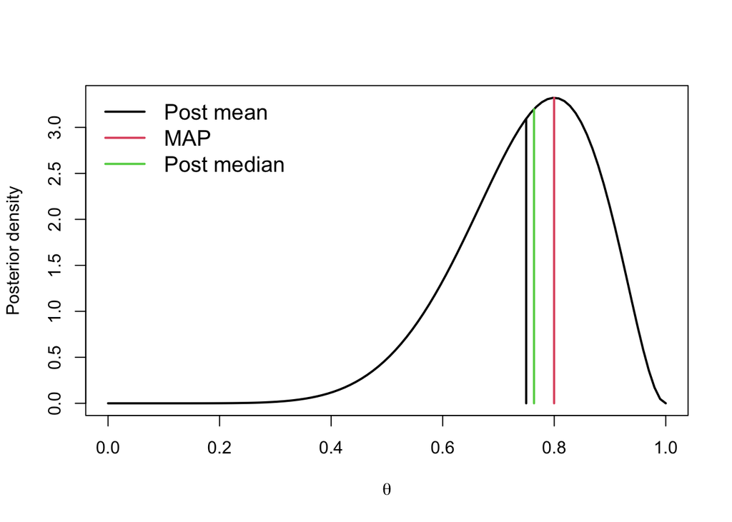

```r
vline <- function(x, A, B, lwd=1, col=1, lty=1)
{
  theta <- seq(0, 1, length=1000)
  k     <- theta[which.min(abs(theta-x))]
  lines(c(k,k), c(0,dbeta(k,A,B)), lwd=lwd, col=col, lty=lty)
}

MAP <- (A-1)/(A+B-2)     # Posterior mode

MN  <- A/(A+B)           # Posterior mean

MD  <- qbeta(0.5, A, B)  # Posterior median

theta <- seq(0,1,length=100)

plot(theta,dbeta(theta,A,B), lwd=2, type="l",
     xlab=expression(theta), ylab="Posterior density")

vline(MN,  A, B, lwd=2, col=1)

vline(MAP, A, B, lwd=2, col=2)

vline(MD,  A, B, lwd=2, col=3)

legend("topleft",c("Post mean","MAP","Post median"),
       col=1:3, lwd=2, bty="n", cex=1.25)
```

### Bayesian credible intervals

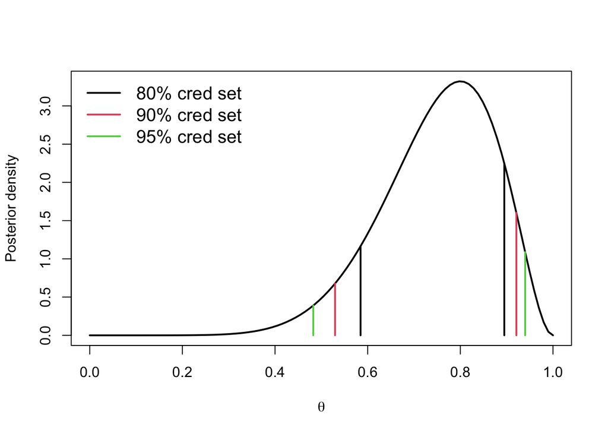

```r
plot(theta, dbeta(theta,A,B), type="l", lwd=2,
     xlab=expression(theta), ylab="Posterior density")

vline(qbeta(0.1,  A,B), A, B, lwd=2, col=1)

vline(qbeta(0.9,  A,B), A, B, lwd=2, col=1)

vline(qbeta(0.05, A,B), A, B, lwd=2, col=2)

vline(qbeta(0.95, A,B), A, B, lwd=2, col=2)

vline(qbeta(0.025,A,B), A, B, lwd=2, col=3)

vline(qbeta(0.975,A,B), A, B, lwd=2, col=3)

legend("topleft",
       c("80% cred set","90% cred set","95% cred set"),
       col=1:3, lwd=2, bty="n", cex=1.25)
```